# Return Analysis

- Annualized returns
- Annualized volatility
- Drawdown at each timestep
- Maximum drawdown
- Semideviation
- Conditional Value at Risk
- Sharpe Ratio
- Skewness of returns distribution
- Kurtosis of returns distribution
- Test for normality
- Monthly parametric Gaussian Value at Risk (VaR)
- Monthly parametric Gaussian VaR with Cornish-Fisher adjustment
- Monthly historic VaR

```python
import numpy as np
import pandas as pd
import matplotlib.pyplot as plt
import edhec_risk_kit_206 as erk
```

#### Retrieve the monthly returns for 49 industries from 1960 to 2018

```python
df = erk.get_ind_returns(n_inds=49)['1960':]
```

### Annualized returns

Annualizing returns allow us to compare returns over different lengths of time. If you are annualizing a return for an investment that took less than a year, you can think of the annualized return as the total return if you had continued seeing that rate of return for a full year.

$r_a = (1 + r_{\text{total}})^{P/n} - 1$

where $P$ is the number of periods per year.

and $n$ is the number of periods.

If we have a set of 25 monthly returns, $P=12$ and $n=25$

If we have a set of 3 quarterly returns, $P=4$ and $n=3$

If we have an investment that returned 9% over 2 years, $P=1$ and $n=2$

For example, if you have an investment that returned 0.5% over one month, the annualized return would be equal to $(1 + 0.005)^{12} - 1 = 6.17$%.

If you have an investment that returned 1% over two months, the annualized return would be equal to $(1 + 0.01)^{12/2} - 1 = 6.15$%.

If you have an investment that returned 15% over 3 years, the annualized return would be equal to $(1 + 0.15)^{1/3} - 1 = 4.77$%.

If you have an investment that retured 15% over 28 months, the annualized return would be equal to $(1 + 0.15)^{12/28} - 1 = 6.17$%.

```
def annualize_rets(r, periods_per_year):
    """
    Annualizes a set of returns
    """
    compounded_growth = (1+r).prod()
    n_periods = r.shape[0]
    return compounded_growth**(periods_per_year/n_periods)-1
```

Consider a portfolio holding 100% Beer industry stocks.

Calculate the annualized return.

```python
erk.annualize_rets(df['Beer'], periods_per_year=12)
```

```
0.11920634382896678
```

### Annnualized volatility

$\sigma_a = \sigma * \sqrt{P}$

Where $\sigma$ is the standard deviation of the returns and $P$ is the number of periods per year.

$\sigma = \sqrt{\frac{\sum_{i=0}^{N}(x_i-\mu)^2}{N-1}}$

```
def annualize_vol(r, periods_per_year):
    """
    Annualizes the vol of a set of returns
    """
    return r.std()*(periods_per_year**0.5)
```

Calculate the annualized volatility of the returns

```python
erk.annualize_vol(df['Beer'], periods_per_year=12)
```

```
0.17519063591781509
```

### Drawdown

Drawdown is equal to the value of a portfolio, at a given timestep, subtracted from historical maximum value of the portfolio, expressed as a percentage loss.

#### $\text{Drawdown at time T} = \frac{(\max \limits_{t\in (0,T)} X(t) ) - X(T)}{\max\limits_{t\in (0,T)} X(t)}$

```
def drawdown(return_series: pd.Series):
    """Takes a time series of asset returns.
       returns a DataFrame with columns for
       the wealth index,
       the previous peaks, and
       the percentage drawdown
    """
    wealth_index = 1000*(1+return_series).cumprod()
    previous_peaks = wealth_index.cummax()
    drawdowns = (wealth_index - previous_peaks)/previous_peaks
    return pd.DataFrame({"Wealth": wealth_index,
                         "Previous Peak": previous_peaks,
                         "Drawdown": drawdowns})
```

### Maximum drawdown

Maximum drawdown over the course of an investment.

```python
erk.drawdown(df['Beer'])['Drawdown'].min()*-1
```

```
0.5855330578251526
```

#### What month did max drawdown occur in?

```python
erk.drawdown(df['Beer'])['Drawdown'].idxmin()
```

```
Period('1974-12', 'M')
```

### Semideviation

Semideviation is the standard deviation among the subset of negative asset returns.

```
def semideviation(r):
    """
    Returns the semideviation aka negative semideviation of r
    r must be a Series or a DataFrame, else raises a TypeError
    """
    if isinstance(r, pd.Series):
        is_negative = r < 0
        return r[is_negative].std(ddof=0)
    elif isinstance(r, pd.DataFrame):
        return r.aggregate(semideviation)
    else:
        raise TypeError("Expected r to be a Series or DataFrame")
```

What was the semideviation of the return distribution?

```python
erk.semideviation(df['Beer'])
```

```
0.03417051008448179
```

### Conditional Value at Risk (CVaR)

The conditional value at risk is the expected return given that the return is less than than value at risk.

$\text{CVaR} = -\text{E}(R|R \leq - \text{VaR})$

### $= \frac{-\int_{-\infty}^{-\text{VaR}}x * f_R(x)dx}{F_R(-\text{VaR})}$

```
def cvar_historic(r, level=5):
    """
    Computes the Conditional VaR of Series or DataFrame
    """
    if isinstance(r, pd.Series):
        is_beyond = r <= -var_historic(r, level=level)
        return -r[is_beyond].mean()
    elif isinstance(r, pd.DataFrame):
        return r.aggregate(cvar_historic, level=level)
    else:
        raise TypeError("Expected r to be a Series or DataFrame")
```

```python
erk.cvar_historic(df['Beer'], level=5)
```

```
0.10638611111111114
```

### Sharpe Ratio

The Sharpe ratio for an investment is its excess return divided by the standard deviation of its returns.

#### Sharpe ratio = $\frac{r_a - r_f}{\sigma_a}$

```
def sharpe_ratio(r, riskfree_rate, periods_per_year):
    """
    Computes the annualized sharpe ratio of a set of returns
    """
    # convert the annual riskfree rate to per period
    rf_per_period = (1+riskfree_rate)**(1/periods_per_year)-1
    excess_ret = r - rf_per_period
    ann_ex_ret = annualize_rets(excess_ret, periods_per_year)
    ann_vol = annualize_vol(r, periods_per_year)
    return ann_ex_ret/ann_vol
```

```python
erk.sharpe_ratio(df['Beer'], riskfree_rate=0.02, periods_per_year=12)
```

```
0.5559722618022646
```

### Skewness

Skewness measures the asymmetry of a probability distribution. It is the third standardized moment of a random variable.

#### $\text{Skewness}[X] = \text{E}[(\frac{X-\mu}{\sigma})^3] = \frac{\text{E}[(X - \mu)^3]}{(\text{E}[(X - \mu)^2])^{3/2}}$

Normal distributions have a skessness of 0.

Example of a negative and positibe skew:

[figure not shown]

```
def skewness(r):
    """
    Alternative to scipy.stats.skew()
    Computes the skewness of the supplied Series or DataFrame
    Returns a float or a Series
    """
    demeaned_r = r - r.mean()
    # use the population standard deviation, so set dof=0
    sigma_r = r.std(ddof=0)
    exp = (demeaned_r**3).mean()
    return exp/sigma_r**3
```

What is the skewness of this return distribution?

```python
erk.skewness(df['Beer'])
```

```
-0.010471512193777247
```

Which industry at the most negatively skewed return distribution?

```python
print(erk.skewness(df).idxmin())
```

```
Meals
```

### Kurtosis

Kurtosis is a measure of the size of the tail of a probability distribution. It is the fourth standardized moment of a random variable.

#### $\text{Kurtosis}[X] = \text{E}[(\frac{X-\mu}{\sigma})^4] = \frac{\text{E}[(X - \mu)^4]}{(\text{E}[(X - \mu)^2])^{2}}$

Normal distributions have a kurtosis of 3.

```
def kurtosis(r):
    """
    Alternative to scipy.stats.kurtosis()
    Computes the kurtosis of the supplied Series or DataFrame
    Returns a float or a Series
    """
    demeaned_r = r - r.mean()
    # use the population standard deviation, so set dof=0
    sigma_r = r.std(ddof=0)
    exp = (demeaned_r**4).mean()
    return exp/sigma_r**4
```

What is the kurtosis of this return distribution?

```python
erk.kurtosis(df['Beer'])
```

```
5.446251021883774
```

Which industry had a returns distribution with the largest kurtosis?

```python
print(erk.kurtosis(df).idxmax())
```

```
RlEst
```

### Test for normality

Test whether a distribution of data has a skewness and kurtosis that indicate the data matches a normal distribution.

Calculate the test statistics, $JB = \frac{n}{6}(S^2 + \frac{1}{4}(K-3)^2)$ and choose a $p$-value to test at.

```
def is_normal(r, level=0.01):
    """
    Applies the Jarque-Bera test to determine if a Series is normal or not
    Test is applied at the 1% level by default
    Returns True if the hypothesis of normality is accepted, False otherwise
    """
    if isinstance(r, pd.DataFrame):
        return r.aggregate(is_normal)
    else:
        statistic, p_value = scipy.stats.jarque_bera(r)
        return p_value > level
```

Do these monthly returns follow the normal distribution?

```python
erk.is_normal(df['Beer'], level=0.01)
```

```
False
```

### Monthly parametric Gaussian VaR

```
def var_gaussian(r, level=5, modified=False):
    """
    Returns the Parametric Gauusian VaR of a Series or DataFrame
    If "modified" is True, then the modified VaR is returned,
    using the Cornish-Fisher modification
    """
    # compute the Z score assuming it was Gaussian
    z = norm.ppf(level/100)
    if modified:
        # modify the Z score based on observed skewness and kurtosis
        s = skewness(r)
        k = kurtosis(r)
        z = (z +
                (z**2 - 1)*s/6 +
                (z**3 -3*z)*(k-3)/24 -
                (2*z**3 - 5*z)*(s**2)/36
            )
    return -(r.mean() + z*r.std(ddof=0))
```

```python
erk.var_gaussian(df['Beer'], level=1)
```

```
0.10686670592419344
```

### Monthly parametric Gaussian VaR with Cornish-Fisher adjustment

```python
erk.var_gaussian(df['Beer'], level=1, modified=True)
```

```
0.13615629641279908
```

# Compare returns between industries

### Which industries had the highest and lowest annual returns?

```python
ind_highest_ret = erk.annualize_rets(df, periods_per_year=12).idxmax()
ind_lowest_ret = erk.annualize_rets(df, periods_per_year=12).idxmin()
print('Industry with highest annualized return: {0}'.format(ind_highest_ret))
print('Industry with lowest annualized return: {0}'.format(ind_lowest_ret))
```

```
Industry with highest annualized return: Smoke
Industry with lowest annualized return: Softw
```

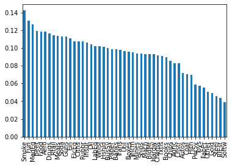

```python
erk.annualize_rets(df, periods_per_year=12).sort_values(ascending=False).plot.bar()
plt.show()
```

### Display summary stats of all the industries

```python
erk.summary_stats(df)
```

|  | Annualized Return | Annualized Vol | Skewness | Kurtosis | Cornish-Fisher VaR (5%) | Historic CVaR (5%) | Sharpe Ratio | Max Drawdown |
| --- | --- | --- | --- | --- | --- | --- | --- | --- |
| Agric | 0.083174 | 0.227038 | 0.023787 | 4.363072 | 0.096661 | 0.132867 | 0.227664 | -0.670659 |
| Food | 0.119149 | 0.152597 | 0.115850 | 4.983611 | 0.058799 | 0.088451 | 0.568450 | -0.431249 |
| Soda | 0.113355 | 0.216873 | 0.128246 | 7.327176 | 0.083630 | NaN | 0.382608 | -0.641812 |
| Beer | 0.119206 | 0.175191 | -0.010472 | 5.446251 | 0.070081 | 0.106386 | 0.495398 | -0.585533 |
| Smoke | 0.142585 | 0.210531 | -0.103832 | 5.398053 | 0.085722 | 0.125156 | 0.520244 | -0.598755 |
| Toys | 0.057655 | 0.253771 | -0.113638 | 4.188872 | 0.113619 | 0.152744 | 0.105735 | -0.736080 |
| Fun | 0.131444 | 0.263804 | -0.207285 | 5.760808 | 0.112079 | 0.168928 | 0.373933 | -0.801774 |
| Books | 0.089811 | 0.203934 | -0.020507 | 4.931956 | 0.085892 | 0.122044 | 0.285198 | -0.774217 |
| Hshld | 0.101864 | 0.162928 | -0.292402 | 4.694151 | 0.070307 | 0.101906 | 0.429105 | -0.574849 |
| Clths | 0.107625 | 0.219375 | -0.068181 | 5.607062 | 0.091421 | 0.130592 | 0.344121 | -0.762776 |
| Hlth | 0.069990 | 0.281037 | -0.047717 | 5.680109 | 0.119981 | NaN | 0.155862 | -0.918911 |
| MedEq | 0.127348 | 0.184678 | -0.275416 | 4.160521 | 0.079012 | 0.111506 | 0.512834 | -0.492337 |
| Drugs | 0.116519 | 0.174184 | 0.127077 | 5.479912 | 0.067826 | 0.100181 | 0.483245 | -0.481990 |
| Chems | 0.092195 | 0.189459 | -0.120480 | 5.265948 | 0.080380 | 0.111681 | 0.319275 | -0.583971 |
| Rubbr | 0.107496 | 0.207486 | -0.199289 | 5.539226 | 0.088381 | 0.129586 | 0.363263 | -0.648013 |
| Txtls | 0.091117 | 0.244169 | 0.392389 | 12.301449 | 0.084808 | 0.152728 | 0.243310 | -0.779751 |
| BldMt | 0.093464 | 0.209022 | -0.049712 | 6.996385 | 0.085866 | 0.129797 | 0.295249 | -0.665138 |
| Cnstr | 0.082722 | 0.247685 | -0.070153 | 3.855379 | 0.108504 | 0.142983 | 0.206857 | -0.711003 |
| Steel | 0.045484 | 0.251254 | -0.162875 | 5.230505 | 0.112896 | 0.156942 | 0.059654 | -0.758017 |
| FabPr | 0.055124 | 0.249383 | -0.098083 | 4.233008 | 0.111157 | NaN | 0.104979 | -0.690458 |
| Mach | 0.093557 | 0.211150 | -0.369449 | 5.430184 | 0.094078 | 0.126862 | 0.292690 | -0.633257 |
| ElcEq | 0.108011 | 0.214048 | -0.185237 | 4.583170 | 0.092302 | 0.124167 | 0.354455 | -0.593946 |
| Autos | 0.071905 | 0.228836 | 0.230954 | 9.082331 | 0.088097 | 0.136975 | 0.177937 | -0.779595 |
| Aero | 0.118798 | 0.228049 | -0.276653 | 4.674337 | 0.099480 | 0.136942 | 0.378695 | -0.752222 |
| Ships | 0.093981 | 0.244914 | -0.008068 | 4.690134 | 0.103950 | 0.143703 | 0.253947 | -0.675484 |
| Guns | 0.113285 | 0.226587 | -0.150289 | 5.003679 | 0.095932 | NaN | 0.365874 | -0.616820 |
| Gold | 0.049120 | 0.361926 | 0.746524 | 7.875271 | 0.128664 | NaN | 0.055956 | -0.774343 |
| Mines | 0.094162 | 0.253065 | -0.273353 | 4.901837 | 0.112611 | 0.150928 | 0.246433 | -0.668831 |
| Coal | 0.070662 | 0.350241 | 0.172015 | 5.175953 | 0.145936 | 0.212617 | 0.112539 | -0.973579 |
| Oil | 0.104085 | 0.186097 | 0.032862 | 4.250474 | 0.076726 | 0.110556 | 0.387243 | -0.492375 |
| Util | 0.096788 | 0.137050 | -0.119541 | 4.113629 | 0.056965 | 0.079622 | 0.474155 | -0.423764 |
| Telcm | 0.095363 | 0.159542 | -0.182987 | 4.157287 | 0.068313 | 0.098486 | 0.398556 | -0.717741 |
| PerSv | 0.059159 | 0.235580 | -0.153172 | 4.435327 | 0.105610 | 0.145814 | 0.120165 | -0.934697 |
| BusSv | 0.100435 | 0.193429 | -0.365137 | 5.353391 | 0.085200 | 0.119292 | 0.354170 | -0.664484 |
| Hardw | 0.092986 | 0.241226 | -0.197878 | 4.711917 | 0.106036 | 0.148506 | 0.253822 | -0.841621 |
| Softw | 0.038944 | 0.391038 | 0.824403 | 8.089024 | 0.136404 | NaN | 0.028968 | -0.994419 |
| Chips | 0.085819 | 0.252321 | -0.350978 | 4.651943 | 0.114807 | 0.160097 | 0.214979 | -0.844654 |
| LabEq | 0.102067 | 0.239016 | -0.192208 | 4.204502 | 0.104928 | 0.143597 | 0.293155 | -0.688579 |
| Paper | 0.099032 | 0.190371 | 0.105606 | 5.107522 | 0.076935 | 0.108422 | 0.352703 | -0.586680 |
| Boxes | 0.096132 | 0.192433 | -0.367518 | 4.949687 | 0.085546 | 0.122003 | 0.334239 | -0.584344 |
| Trans | 0.098112 | 0.198207 | -0.230970 | 4.219214 | 0.086864 | 0.118936 | 0.334213 | -0.570126 |
| Whlsl | 0.102002 | 0.192453 | -0.321769 | 5.195884 | 0.084144 | 0.118522 | 0.363894 | -0.626924 |
| Rtail | 0.115013 | 0.184761 | -0.186114 | 5.130936 | 0.077623 | 0.108631 | 0.447615 | -0.574016 |
| Meals | 0.113795 | 0.208563 | -0.441333 | 5.503921 | 0.092388 | 0.133078 | 0.390778 | -0.722291 |
| Banks | 0.098853 | 0.204399 | -0.271116 | 4.984177 | 0.089447 | 0.126464 | 0.327602 | -0.746194 |
| Insur | 0.106165 | 0.195484 | -0.029171 | 5.157407 | 0.080736 | 0.117072 | 0.378981 | -0.681065 |
| RlEst | 0.043870 | 0.268589 | 0.826531 | 14.366781 | 0.083934 | 0.164833 | 0.049927 | -0.879534 |
| Fin | 0.111502 | 0.209095 | -0.387515 | 4.350789 | 0.093354 | 0.130994 | 0.379114 | -0.686448 |
| Other | 0.050744 | 0.237110 | -0.430036 | 4.662264 | 0.111809 | 0.162894 | 0.084835 | -0.925342 |